# Database Management end of Course Project SQL/ NoSQL Project

Kevin Da Silva, Alberto Monari, Antoine Settelen, Simon Weiss

2020-11-17

## PART I: SQL PROJECT

### Project description:

BAKERS is a software development company that has been existing since the 1980s. With the current evolution in AI and business analytic, they are far behind the competition in terms of **productivity**. The CEO believes the issue comes from his employees so he decides to hire a new human resource **(HR) manager**. The new HR manager is who just arrived seeks to understand the employee structure of the company to determine if the employees could be the reason why the company is not very competitive in today’s software business industry and how to solve this issue if it is the case. To this end, the HR manager learns that there is a database that contains **all information on the employees in the company** and also learns that there is a business analysis team in the company that provides analytic support to other departments. HR decides to reach out to have their informed opinion on the current situation of employees in the company and what could be done to improve the situation.

### Exercise

You are the **team of business analysts** working for BAKERS. Based on the HR’s request, you are expected to make at least **15 recommendations** on how to improve the **state** and **conditions** of employees in the company to make it **more competitive** in its industry. Be creative - your advice can be anything meaningful for the HR (e.g. hire new staff, increase salaries for a given group of employees, fire some employees, etc.). All your justifications **MUST be based on evidence from the database**. Each suggestion should be presented in four subsections:

- Query
- Result
- Analysis/interpretation
- Recommendations

HR has also provided a **list of requests** that must be completed. You are expected to provide a minimum of **10 recommendations** based on the requests of the HR, and a minimum of **five recommendations based on queries** you conceived as an expert. One query can lead to more than one recommendation.

Follow the instructions carefully. Do not provide irrelevant columns. All your column titles should bare meaningful and well-formatted headings. For example, do not provide employee ID if it is not necessary/required to understand your suggestion. However, your tables should have rich content for the manager. For example, if the list of employees with the lowest salary is requested, it will be better if you provide the name of the employee, the salary earned, and add the department and/or job title or years of experience to help develop interesting insights and arguments.

List of queries that must be completed for the HR. The HR manager will like you to please provide the following information (remember: the queries and the results (provide first 10 rows if the result is a table)):

1. List of employees with the following information: First name, last name, gender, age, number of years spent in the company, department, the year they joined the department, and their current job title.
2. The number of employees per department.
3. List of employees per department, their positions, and salaries. Make a separate list for each department.
4. List of the average salary of employees in each job position (title).
5. List of the average age of employees in (i) the company, (ii) each department, (iii) each job position.
6. What is the ratio of me to women in (i) each department; (ii) each job position (title).
7. List of employees with (i) the lowest salary, (ii) the highest salary (iii) above average salary. Please do not forget to mention the lowest and highest salary amount. The currency is Euro.
8. List of employees who joined the company in December.
9. List of the most experienced employees (by the number of years) in each department and the company as a whole.
10. List of the most recently hired employees (that is, the year the most recent employee was recruited).

To meet your objectives, the database administrator has provided you with a MySQL database for employees. Figure 1 presents the database schema. You are expected to query the database provided to obtain the information necessary for you to advise the new HR. To setup the database, it suffices to import the “employees.sql” file in the employees zipped folder provided. DO NOT DELETE ANY FILE IN THE FOLDER PROVIDED! Make sure to use MySQL workbench or MySQL shell to avoid incompatibilities.

### Hypothesis used for the analysis

The department’s analytic team would like to specify the main hypothesis after receiving this database. All the analyses are carried out at the **date 2020**. We therefore place ourselves in the situation where the database we received from HR is **up to date for this year**.

### Query 1 : List of employees with information.

List of employees with the following information: First name, last name, gender, age, number of years spent in the company, department, the year they joined the department, and their current job title.

```sql
SELECT first_name, last_name, gender, dept_name, TIMESTAMPDIFF(YEAR,birth_date,NOW()) AS age, TIMESTAMPDIFF(YEAR,hire_date,NOW()) AS years_in_the_company, dept_name, YEAR(de.from_date) AS year_of_entrance_in_the_department, title
FROM employees AS e
INNER JOIN dept_emp AS de
ON e.emp_no = de.emp_no
INNER JOIN departments AS d
ON de.dept_no = d.dept_no
INNER JOIN titles AS t
ON e.emp_no = t.emp_no
WHERE t.to_date > CURDATE() #include only current job title for those who had more than one job title in the company
AND de.to_date > CURDATE() #esclude the people who are now retired
ORDER BY 1, 2
LIMIT 10;
```

#### Result

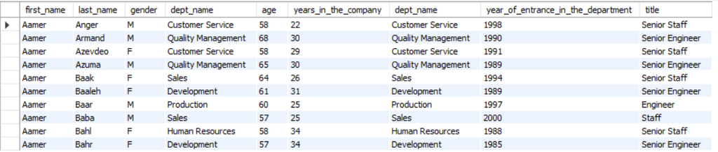

List of employees with informations

#### Analysis

The database given by the database administrator is well structured and seems to be of good quality as we can clearly read on this first query.  
This first query provides an overview of the employees by aggregating information from different tables.

#### Recommendations

If it is not already done, it would be possible **to export this table** to the HR department **in csv or excel** so that the department has a database that can be used by them and updated.

### Query 2 : The number of employees per department

```sql
SELECT dept_name, COUNT(*) AS nb_of_employes
FROM dept_emp AS de
INNER JOIN departments AS d
ON d.dept_no = de.dept_no
WHERE de.to_date > CURDATE() #exclude the people who are not anymore in the department (retired, who left the company, who changed the department...)
GROUP BY d.dept_no
ORDER BY 2 DESC;
```

#### Result

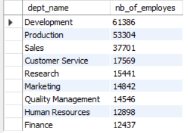

The number of employees per department

#### Analysis

Baker’s HR structure seems to rely primarily on an **active pool of developers and producers**. Supported by the third largest department in terms of employees, Sales, these two departments deploy and produce software and then sell it.

#### Recommendations

This seems to be a very classic structure of a software company developing in the 2000s. However, we can notice the very low weight of the research department, essential in the AI sector and the customer service department, crucial in the analytics business (understanding and accompanying the customer needs and not only selling at any price).  
Thus, one could recommend more **interdepartmental transfers**. Encourage developers to go to the **research department** for some time or foster recruitment in **under-represented but strategic departments**.

### Query 3 : List of employees per department, their positions, and salaries.

```sql
SELECT first_name, last_name, dept_name, salary, title
FROM employees AS e
INNER JOIN dept_emp AS de
ON de.emp_no = e.emp_no
INNER JOIN departments AS d
ON de.dept_no = d.dept_no
INNER JOIN  salaries AS s
ON e.emp_no = s.emp_no
INNER JOIN titles AS t
ON e.emp_no = t.emp_no
WHERE de.to_date > CURDATE() #exclude the people who are not anymore in the department (retired, who left the company, who changed the department...)
AND t.to_date > CURDATE() #include only current job title for those who had more than one job title in the company
AND s.to_date > CURDATE() #include only current salary
ORDER BY 3, 2, 1
LIMIT 10;
```

Make a separate list for each department.

```sql
SELECT departments.dept_name as 'Department', GROUP_CONCAT(
CONCAT_WS(', ', employees.first_name, employees.last_name,  titles.title,  salaries.salary) SEPARATOR " / " )
as 'Employees, their positions and their salaries'
FROM employees
INNER JOIN dept_emp ON dept_emp.emp_no = employees.emp_no
LEFT JOIN departments ON departments.dept_no = dept_emp.dept_no
INNER JOIN titles ON titles.emp_no = employees.emp_no
INNER JOIN salaries ON salaries.emp_no = employees.emp_no AND salaries.to_date = '9999-01-01'
GROUP BY departments.dept_no;
```

#### Result

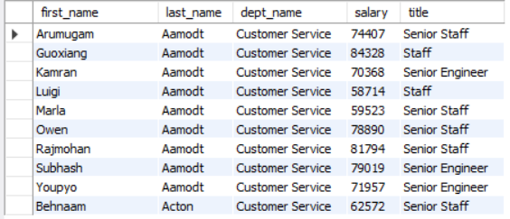

List of employees per department, their positions, and salaries.

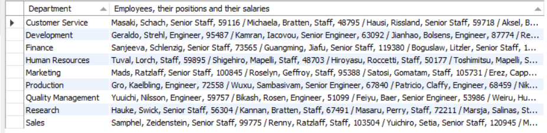

Seperated list for each department

#### Recommendations

These lists can be sent to the HR department **in csv or xls format for further internal analysis.**

### Query 4 : List of the average salary of employees in each job position (title).

```sql
SELECT title, ROUND(AVG(salary)) AS avg_salary
FROM salaries AS s
INNER JOIN titles AS t
ON  s.emp_no = t.emp_no
WHERE s.to_date > CURDATE() #include only current salary
AND t.to_date > CURDATE() #include only current job title for those who had more than one job title in the company
GROUP BY 1
ORDER BY 2 DESC;
```

#### Result

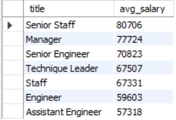

List of the average salary of employees in each job position (title)

#### Analysis

According to indeed.com data, the average salary for a engineer is **$71,220 per year** in the United States (november 2020) and **$107,376 per year** for Software Engineer. Here we can observe a **considerable gap** between these average figures and the average engineer’s salary. One could assume that salaries are not updated to 2020, but this would contradict our initial hypothesis. In any case this gap seems significant with market prices.  
Talent recruitment is a key point to maintain productivity and competitiveness in the software market.

#### Recommendations

Thus, a first recommendation would be to **increase the salary level of engineers** and review recruitment strategies in order to attract the most **competitive engineers on the market.**

For the other positions, the analysis team does not have enough data to truly make definitive recommendations. However, Bakers HR department could review its salary policy to ensure that staff and technical leaders, who are better paid than the average engineer, **bring truly productivity among teams.**

### Query 5 : List of the average age of employees

#### Query 5.1 : List of the average age of employees in (i) the company

```sql
SELECT AVG(TIMESTAMPDIFF(year,birth_date,NOW())) AS avg_age
FROM employees AS e;
```

[output not shown]

#### Analysis

This average age is extremely high for a technology company. According to [Business Insider](https://i.insider.com/59b69ba145e2381d008b64f5?width=800&format=jpeg&auto=webp), the average age of IBM employee was **38 in 2017 and 33 years old for Microsoft**.

#### Recommendations

Are “young people just smarter”, as Mark Zuckerberg claimed in 2007, or are young people better able to **bring about technological change** and increase their company’s competitiveness? We leave this answer to the Strategic teams. It seems clear, however, that Backer has a real need to review its **recruitment policy**, which for the most part allowed its former employees recruited in the 1980s **to end their careers here**, closing the doors to younger people.

#### Query 5.2 : Each department

```sql
SELECT dept_name, AVG(TIMESTAMPDIFF(year,birth_date,now())) AS avg_age
FROM employees AS e
INNER JOIN dept_emp AS de
ON e.emp_no = de. emp_no
INNER JOIN departments AS d
ON d.dept_no = de.dept_no
WHERE de.to_date > CURDATE()  #exclude the people who are not anymore in the department (retired, who left the company, who changed the department...)
GROUP BY 1
ORDER BY 2;
```

#### Result

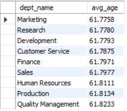

#### Analysis

The average age per department is **homogeneous,** there are no departments that are really younger or older. The analysis observed in 5.1 is confirmed. Let’s analyse average age by job position.

#### Recommendations

Same Recommendations 5.1.

#### Query 5.3 : Each job position

```sql
SELECT title, AVG(TIMESTAMPDIFF(year,birth_date,now())) AS avg_age
FROM employees AS e
INNER JOIN titles AS t
ON e.emp_no = t. emp_no
WHERE t.to_date > CURDATE() #include only current job title for those who had more than one job title in the company
GROUP BY 1
ORDER BY 2;
```

#### Result

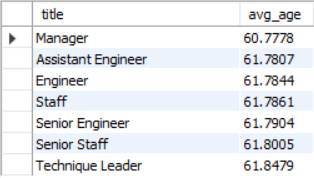

Each job position

#### Analysis

Managers are on average 1 year younger than other employees of the company. This small difference does not change **analysis 5.1, which remains the main analysis**. The structure of middle-aged positions remains very old in line with other companies in the sector.

#### Recommendations

Recruitment of younger people, more trainings between senior and junior,

### Query 6 : What is the ratio of men to women

#### Query 6.1 : What is the ratio of men to women in (i) each department

```sql
SELECT dept_name, SUM(CASE WHEN gender = "M" THEN 1 ELSE 0 END)/SUM(CASE WHEN gender = "F" THEN 1 ELSE 0 END) AS men_women_ratio
FROM employees AS e
INNER JOIN dept_emp AS de
ON e.emp_no = de. emp_no
INNER JOIN departments AS d
ON d.dept_no = de.dept_no
WHERE de.to_date > CURDATE()  #exclude the people who are not anymore in the department (retired, who left the company, who changed the department...)
GROUP BY 1
ORDER BY 2;
```

#### Result

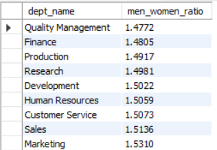

The ratio of men to women in each department

#### Analysis

As many technology companies, the ratio of men employed in our company is **more important than the ratio of women.** However, although it requires greater efforts to erase this gap, we can note that the ratio in our company **is not as important as the ratio in GAFAM**. Indeed, according to Statistica, in 2020 about **25% of GAFAM’s employees** are female and the ratio of men to women in engineering is **5:1.** The average ratio within our company seems to be around **1.5.**

#### Recommendations

Technology, and more particularly Artificial Intelligence, cannot be achieved without **a true cultural and gender mix.** Tomorrow’s AI will have to talk **to everyone.** Recruitment that is more attentive to gender diversity is essential, as well as support for the training of women developers and will bring **key factors of competitiveness to the market.**

#### Query 6.2 : (ii) each job position (title)

```sql
SELECT title, SUM(CASE WHEN gender = "M" THEN 1 ELSE 0 END)/SUM(CASE WHEN gender = "F" THEN 1 ELSE 0 END) AS men_women_ratio
FROM employees AS e
INNER JOIN titles AS t
ON e.emp_no = t.emp_no
WHERE t.to_date > CURDATE() #include only current job title for those who had more than one job title in the company
GROUP BY 1
ORDER BY 2;
```

#### Result

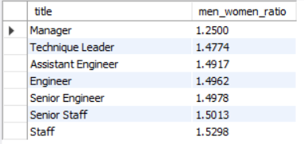

Each job position (title)

#### Analysis

We can observe a significant reduction **in the ratio of men in management positions**.

#### Recommendations

This decrease is to be congratulated and **encouraged for all management positions**.

### Query 7 : List of employees with (i) the lowest salary, (ii) the highest salary (iii) above average salary.

#### Query 7.1 : List of employees with (i) the lowest salary

```sql
SELECT first_name, last_name, min_salary, gender, TIMESTAMPDIFF(YEAR,birth_date,NOW()) AS age, TIMESTAMPDIFF(YEAR,hire_date,NOW()) AS years_in_the_company
FROM employees AS e
INNER JOIN salaries AS s
ON e.emp_no = s.emp_no
INNER JOIN (SELECT MIN(salary) AS min_salary FROM salaries) AS m
ON s.salary = m.min_salary
WHERE s.to_date > CURDATE() #include only current salary
ORDER BY 3;
```

#### Result

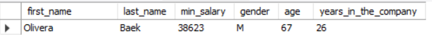

List of employees with (i) the lowest salary

#### Query 7.2 : the highest salary

```sql
SELECT first_name, last_name, max_salary, gender, TIMESTAMPDIFF(YEAR,birth_date,NOW()) AS age, TIMESTAMPDIFF(YEAR,hire_date,NOW()) AS years_in_the_company
FROM employees AS e
INNER JOIN salaries AS s
ON e.emp_no = s.emp_no
INNER JOIN (SELECT MAX(salary) AS max_salary FROM salaries) AS m
ON s.salary = m.max_salary
WHERE s.to_date > CURDATE() #include only current salary
ORDER BY 3 DESC;
```

#### Result

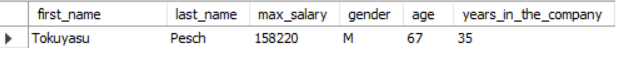

the highest salary

#### Query 7.3 : above average salary

```sql
SELECT first_name, last_name, salary, gender, TIMESTAMPDIFF(YEAR,birth_date,NOW()) AS age, TIMESTAMPDIFF(YEAR,hire_date,NOW()) AS years_in_the_company
FROM employees AS e
INNER JOIN salaries AS s
ON e.emp_no = s.emp_no
WHERE salary > (SELECT AVG(salary) FROM employees.salaries)
AND s.to_date > CURDATE() #include only current salary
ORDER BY 3 DESC
LIMIT 10
```

#### Result

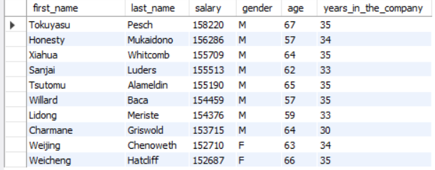

Above average salary

#### Analysis

In general, the most important factor influencing the salary is the **number of years in the company:** in fact, the one with the highest salary in the company has worked 9 years longer in the company than the one with the lowest salary in the company. In addition, those who have the highest salary in the company **have worked more than 30 years in the company**. Another factor that influences the salary **is gender**: it can be seen that among those who have the above average salary, **most are male.**

#### Recommendations

The proportionality between the number of years worked in the company and the salary seems logical. Be more careful that for the same number of years worked and role, **there is no gender difference**, so that there are about the same number of males and females in the above-average and below-average salaries.

### Query 8 : List of employees who joined the company in December.

```sql
SELECT first_name, last_name, hire_date,title
FROM employees AS e, titles AS t
WHERE EXTRACT(MONTH FROM hire_date) = 12 AND e.emp_no=t.emp_no
ORDER BY 3 DESC
LIMIT 10;
```

#### Result

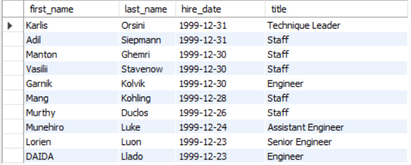

List of employees who joined the company in December

#### Analysis

The majority of the new recruitment **concern staff.** For two new engineers, one assistant and one senior are recruited with one technique leader. This suggests that there is already a change in the company’s recruitment policy. By recruiting more staff, and not more engineers, the company is relying on its pool of engineers.

#### Recommendations

Recruitment of more **young engineers, decelerate the recruitment of senior engineers, promote assistant and senior training.**

### Query 9 : List of the most experienced employees (by the number of years) in each department and the company as a whole.

```sql
SELECT first_name, last_name, dept_name, YEAR(CURDATE())-YEAR(hire_date) AS 'Years in the company'
FROM employees AS e
INNER JOIN dept_emp AS de
ON e.emp_no = de.emp_no
INNER JOIN departments AS d
ON de.dept_no = d.dept_no
WHERE de.to_date > CURDATE()
AND ((dept_name, (YEAR(CURDATE())-YEAR(hire_date))) IN (
    SELECT dept_name, max(YEAR(CURDATE()) - YEAR(hire_date)) AS 'Most experimented'
    FROM employees AS e
    INNER JOIN dept_emp AS de
    ON e.emp_no = de.emp_no
    INNER JOIN departments AS d
    ON de.dept_no = d.dept_no
    WHERE de.to_date > CURDATE()
    GROUP BY 1
    ))
    ORDER BY 4 DESC
    LIMIT 10;
```

#### Result

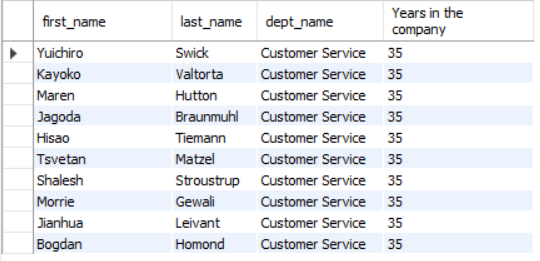

List of the most experienced employees

#### Recommendations

However, if a change in HR policy is confirmed by recruiting more young developers and focusing more on the AI sectors, a **renewal of employees within Customer Service is to be considered**. This is indeed justified by the increasing demand for support of companies within the IA and BA.

### Query 10 : List of the most recently hired employees (that is, the year the most recent employee was recruited)

```sql
SELECT first_name, last_name, dept_name, YEAR(CURDATE())-YEAR(hire_date) AS 'Years in the company'
FROM employees AS e
INNER JOIN dept_emp AS de
ON e.emp_no = de.emp_no
INNER JOIN departments AS d
ON de.dept_no = d.dept_no
WHERE de.to_date > CURDATE() AND YEAR(CURDATE())-YEAR(hire_date) = (
        SELECT MIN(YEAR(CURDATE())-YEAR(hire_date))
        FROM employees)
ORDER BY 4, 3
LIMIT 10;
```

#### Result

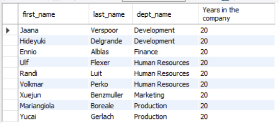

List of the most recently hired employees

#### Analysis

No new recruitment since 20 years.

#### Recommendations

Either the database is good and here our analytic team **urgently recommends to hire new engineers.** Or our team recommends an improvement in the communication regarding the HR database. It must be **urgently** updated by the **database administrator** for a complete and accurate analysis.

### Query 11 : Percentage of current job position in the company

```sql
SELECT title, COUNT(title) AS nb_of_employees, CONCAT(COUNT(title)*100/(SELECT COUNT(*) FROM titles WHERE to_date > CURDATE()), " %") AS percentage
FROM titles
WHERE to_date > CURDATE()
GROUP BY 1
ORDER BY 1;
```

#### Result

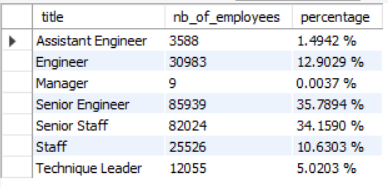

Percentage of current job position in the company

#### Recommendations

A first recommendation is to reduce the gap between the number of seniors and the number of engineers and staff in order to **rejuvenate the company in terms of age** and to have fresh forces ready to work at the top of the senior category. A second recommendation is to **increase the number of managers** a bit, as only 9 managers running a company with more than 100000 employees seem to be very few.

### Query 12 : Average salary per gender and job position combined

```sql
SELECT title, gender, ROUND(AVG(salary)) AS avg_salary
FROM salaries AS s
INNER JOIN titles AS t
ON  s.emp_no = t.emp_no
INNER JOIN employees AS e
ON s.emp_no = e.emp_no
WHERE s.to_date > CURDATE() #include only current salary
AND t.to_date > CURDATE() #include only current job title for those who had more than one job title in the company
GROUP BY 1, 2
ORDER BY 1, 2;
```

#### Result

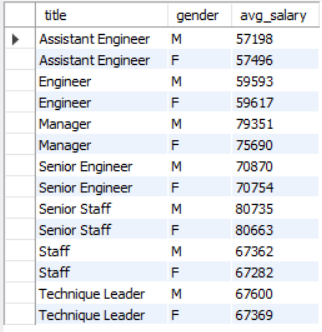

Average salary per gender and job position combined

#### Analysis

The average salary in all job categories is **very similar between males and females,** except for the managers category.

#### Recommendations

In order to avoid gender inequalities, it is necessary to try to have the same salary for men and women in every job category, especially managers (if they are at the same level), because a manager who earns less than another just because of gender **can negatively affect the whole environment.**

### Query 13 : Average salary per year in the company

```sql
SELECT YEAR(CURDATE())-YEAR(hire_date) AS 'Years in the company', ROUND(AVG(salary)) AS avg_salary
FROM employees AS e
INNER JOIN titles AS t
ON  e.emp_no = t.emp_no
INNER JOIN salaries AS s
ON  s.emp_no = e.emp_no
GROUP BY 1
ORDER BY 1;
```

#### Result

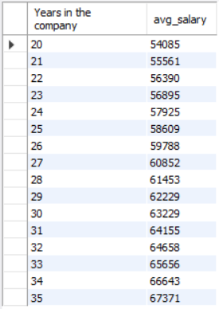

Average salary per years in the company

#### Analysis

There is an almost perfect linear correlation between the years worked in the company and the salary.

#### Recommendations

It seems to us a **logical criterion to base the salary on the number of years** worked in the company so we have no recommendations to make in this respect.

### Query 14 : List of the average, maximum and minimum salary of employees in each job position (title) per department .

```sql
SELECT title, d_name.dept_name, ROUND(MIN(salary)) AS min_salary, ROUND(MAX(salary)) AS max_salary, ROUND(AVG(salary)) AS avg_salary
FROM salaries AS s
INNER JOIN titles AS t
ON  s.emp_no = t.emp_no
INNER JOIN dept_emp AS d
ON d.emp_no = s.emp_no
INNER JOIN departments AS d_name ON d_name.dept_no = d.dept_no
WHERE d.to_date > CURDATE() #include onlu current d
AND s.to_date > CURDATE() #include only current salary
AND t.to_date > CURDATE() #include only current job title for those who had more than one job title in the company
GROUP BY 1, 2
ORDER BY 1, 2 DESC
LIMIT 10;
```

#### Result

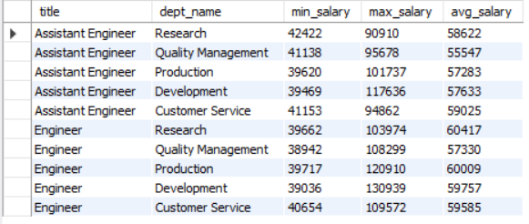

List of the average, maximum and minimum salary of employees in each job position (title) per departement

#### Analysis

Here, we can see that a **job position does not have the same average salary** in all the departments which can increase the inequality between collaborators. In addition, we can see that a job position salary **does not have the same distribution** (minimum - maximum) in all the departments which can increase the inequality between collaborators.

#### Recommendations

**Redistribute wages for the same position** such as the salary does not depend on the department.

### Query 15 : List of the salary distribution in each job position (title) per department and per gender.

```sql
SELECT title, d_name.dept_name, gender, ROUND(MIN(salary)) AS min_salary, ROUND(MAX(salary)) AS max_salary , ROUND(AVG(salary)) AS avg_salary
FROM employees AS e INNER JOIN
salaries AS s ON e.emp_no = s.emp_no
INNER JOIN titles AS t
ON  s.emp_no = t.emp_no
INNER JOIN dept_emp AS d
ON d.emp_no = s.emp_no
INNER JOIN departments AS d_name ON d_name.dept_no = d.dept_no
WHERE d.to_date > CURDATE() #include only current d
AND s.to_date > CURDATE() #include only current salary
AND t.to_date > CURDATE() #include only current job title for those who had more than one job title in the company
GROUP BY 1, 2, 3
ORDER BY 1, 2 , 3 DESC
LIMIT 10;
```

#### Result

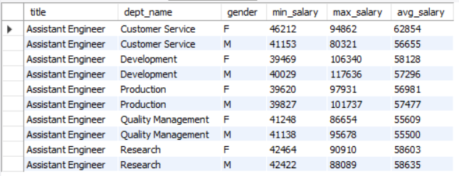

List of the salary distribution in each job position (title) per departement and per gender

#### Recommendations

**Rebalances wages for both gender on the same position** such as the maximum, the minimum salary, the average salary will not depend on the department. Hire some new collaborators and transfer others in order that positions could be equal in terms of gender.

## PART II: NOSQL PROJECT

### Project description:

The mayor of New York will like to reduce pollution in the city by increasing accessibility using public bicycles. You are provided with a **“trips” collection** in the **“citybike” database** found in your MongoDB server. It contains bike trips data from the New York City Citibike service. The documents are composed of: **Bicycle unique identifier**, **Trip start and stop time and date**, **Trip start** and **end stations names** and **geospatial location**, **User information** such as gender, year of birth, and service type (Customer or Subscriber).

### Exercise

A. Write MongoDB queries that will do the following:  
1. Display all documents in the “trips” collection.  
2. Display all documents in the collection except the “tripduration” and “usertype.  
3. Display the”start station name" and “end station name” of all documents in the collection.  
4. Display all the trips to “South St & Whitehall St”.  
5. Display the first 5 trips made by “Subscriber” (usertype).  
6. Display the time of the day with the highest number of trips. 7. Display trips made to end station locations with latitude values greater than 40.735238.  
8. Propose 3 queries that could help understand the behavior of city bikers.  
B. Propose 7 additional queries that would help the mayor understand the movement of New York city bikers.  
C. Based on all the queries above, make suggestions on how New York city biking can be improved. Results should be presented as follows:  
a. Query:  
b. Result:  
c. Analysis/interpretation:  
d. Recommendations:

### Query 1 : Display all documents in the “trips” collection.

Shell

```sql
db.trips.find().pretty()
```

Atlas UI No filter

#### Result

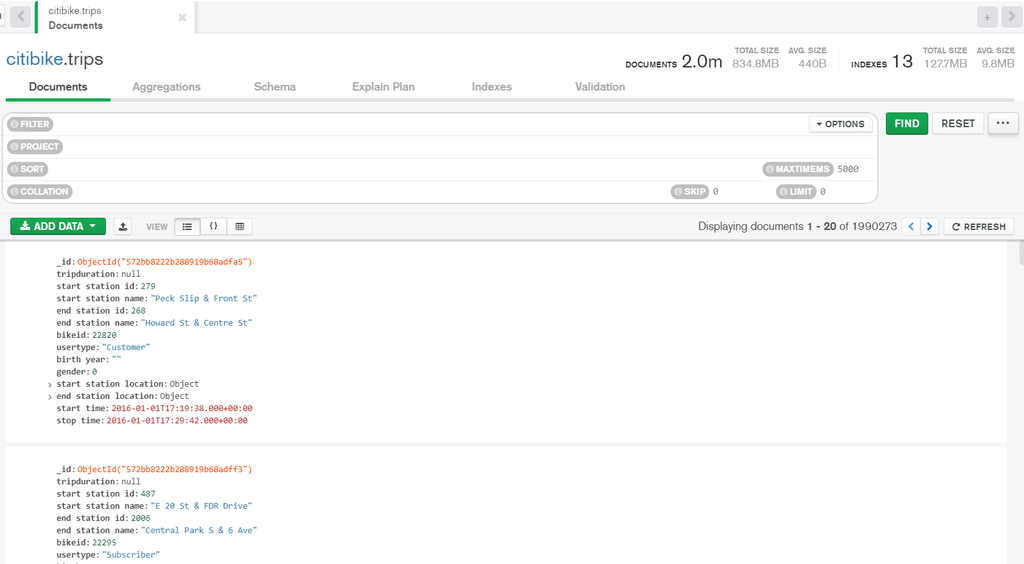

Results 1 - UI

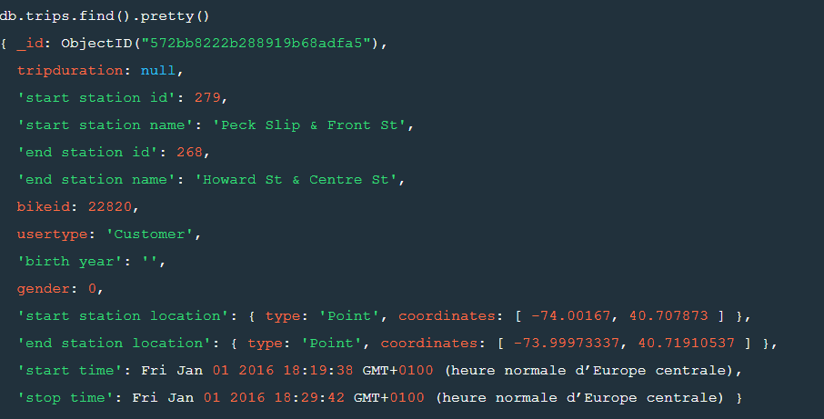

Results 1 - SHELL

#### Analysis

New York City’s citybike database is well-structured. It contains **1 990 273 trips** in a **Document Store** structure encoded into JSON format. The description delivered above of the database corresponds well to the fields in our database.

#### Recommendations

Document Store in MongoDB is a **very good database storage solution.** In case New York City is looking to change its database structure, it could consider **Amazon DynamoDB and a Key-Value Store structure** (key= travel id). **In this case,** it will have to pay attention to the lack of consistency at the database level (no ACID test).

### Query 2 : Display all documents in the collection except the “tripduration” and "usertype.

Shell

```sql
db.trips.find({}, {tripduration :0, usertype:0}).pretty()
```

**Atlas UI**

PROJECT:  
{tripduration :0, usertype:0}

#### Result

[figure not shown]

Results 2 - UI

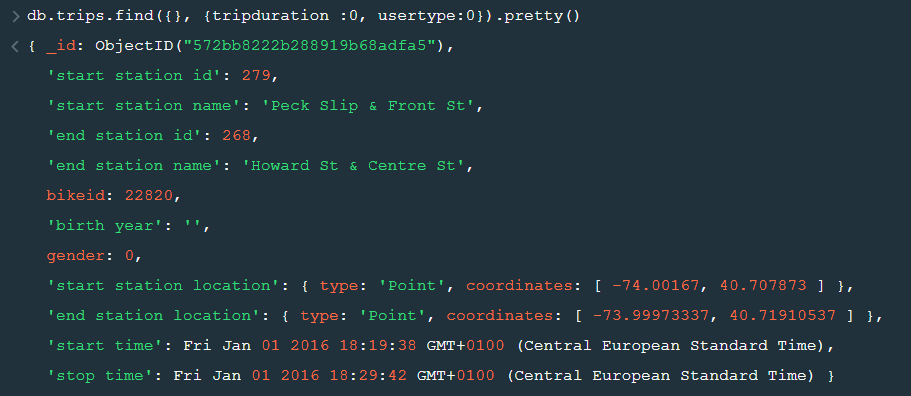

Results 2 - SHELL

#### Analysis

No particular analysis for this query.

### Query 3 : Display the “start station name” and “end station name” of all documents in the collection

Shell

```sql
db.trips.find({}, {'start station name' :1, 'end station name':1, _id:0}).pretty()
```

**Atlas UI**

PROJECT:  
{‘start station name’ :1, ‘end station name’:1, _id:0}

#### Result

[figure not shown]

Results 3 - UI

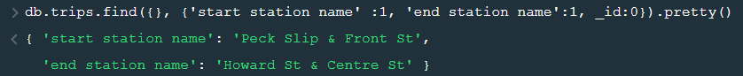

Results 3 - SHELL

#### Analysis

Each start station name and end station name are **well written**.

#### Recommendations

It would be interesting to draw up **a map** of the trips thanks to the coordinates of each station.

### Query 4 : Display all the trips to “South St & Whitehall St”.

Shell

```sql
db.trips.find({"end station name":"South St & Whitehall St"}).pretty()
```

Atlas UI

#### Result

[figure not shown]

Results 4 - UI

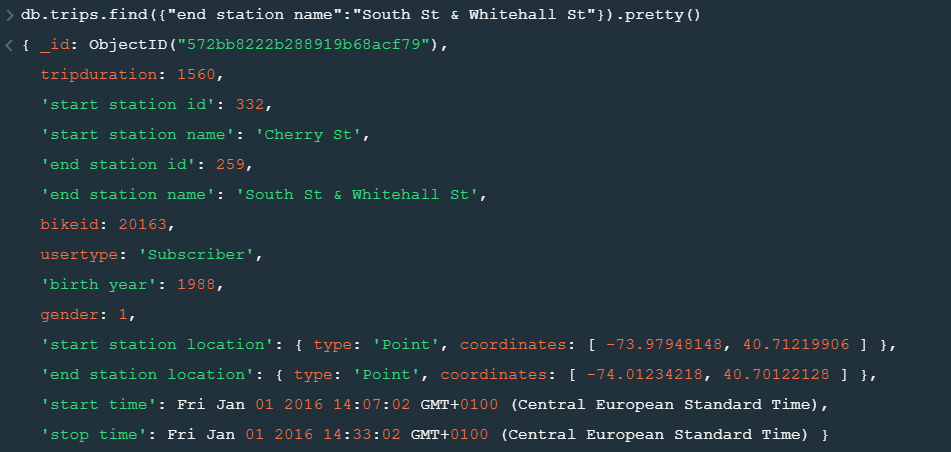

Results 4 - SHELL

#### Analysis

South St & Whitehall St bike station doesn’t seem to be a **very busy station.** Compared to the total number of trips, it totals only 3287 **i.e 0.16 % of total trips**.

#### Recommendation

New York City Hall should be attentive to **underused** stations as well as to stations with **strong influence** during peak hours. Thus, it would be interesting for the town hall to implement **more bike transfers** from less used stations to the most used stations. This could lead to more savings.

### Query 5 : Display the first 5 trips made by “Subscriber” (usertype).

Shell

```sql
db.trips.aggregate([{ $match : {usertype : "Subscriber"}}, { $group: { _id : {start_station_name :"$start station name", end_station_name : "$end station name", usertype : "$usertype"}, count:{$sum:1}}}, {$sort : { count : -1 }}, {$limit : 5} ], {allowDiskUse: true})
```

#### Result

[figure not shown]

Results 5 - UI

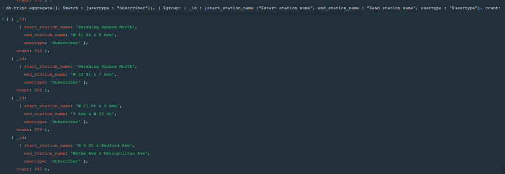

Results 5 - SHELL